# Exploring the Relationship Between Childbirth and Women's Careers: Analyzing Gender Disparities, Employment Status, and Earnings

## Bernice Yuan

- A. Introduction and Motivation
  - a. Motivation
  - b. External Sources
  - c. Hypotheses
- B. The Data Set
  - i. Dataset Introduction
  - ii. Data Cleaning
  - iii. Summary Tables
  - iv. Visualizations
- C. Analysis confidence intervals and testing
  - Hypothesis 1
  - Hypothesis 2
  - Hypothesis 3
- D. Conclusion
- E. References

# A. Introduction and Motivation

## a. Motivation

My initial interest on exploring the relationship between childbirth and women's careers was spurred by my personal experience growing up with my mother who raised two daughters while working full-time. I saw firsthand the challenges and sacrifices that my mother had to make to balance her career and her family responsibilities. Despite her hard work and dedication, she often faced gender disparities in the workplace, such as limited opportunities for promotion. As I grew older and began to learn more about these issues, I became interested in exploring them further and understanding how they affect women more broadly. Women are increasingly entering the workforce and pursuing ambitious career paths, but pregnancy and childbirth can create significant challenges and barriers. Maternity leave, childcare responsibilities, and discrimination in the workplace are just a few of the factors that can make it difficult for women to maintain their careers after having children.

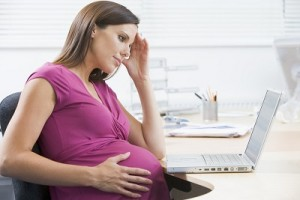

When I was looking for the related literature, I was pleased to find that women's disadvantage in the workplace has attracted more and more attention, and many studies and reports have been published.

## b. External Sources

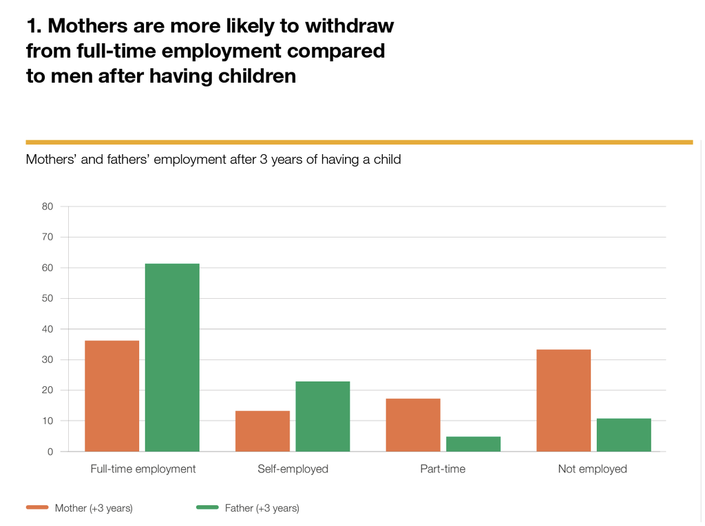

Another research conducted by U.S. Census Bureau found that: for women who only have one child, the rate of workforce participation remains at a lower level than before birth, but stabilizes. However, subsequent births decrease workforce participation further. (Sandler et al 2021)

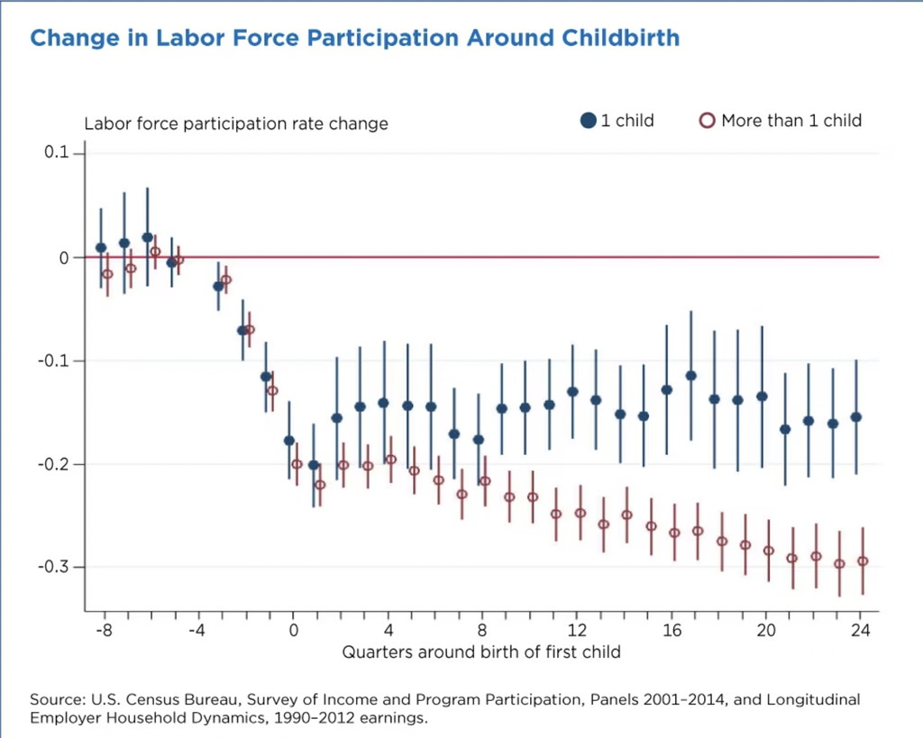

With these two external data in mind, I decide to use the data from IPUMS CPS (CURRENT POPULATION SURVEY) to conduct a multifaceted research.

Firstly, we will investigate whether there are significant differences in employment status and earnings between men with kid(s) and women with kid(s). We hope to gain insights into whether women are inherently disadvantaged in the workplace because of gender-based disparities.

Secondly, we will explore whether an increase in the number of children has a negative impact on women's employment and earnings. We aim to assess the impact of childbirth on women's careers. This analysis will provide important insights into the challenges that women face when balancing work and family responsibilities and identify potential ways to support women in maintaining their careers while also raising a family.

Thirdly, we wonder whether the treatment of mothers in the workplace has improved over the past decade in line with the rapid development of society. This conclusion will measure whether our society's well-being towards the disadvantaged group is progressing.

Overall, this project seeks to provide a comprehensive analysis of the impact of childbirth on women's working careers. By examining a variety of variables, we aim to gain a nuanced understanding of the challenges facing women in the workforce and identify strategies to support women in achieving their career goals.

## c. Hypotheses

Based on the previous information, I present the following hypotheses.

[output not shown]

| Description | Hypothesis |
| --- | --- |
| Null | The more children a woman has, the more likely she is to be unemployed. |
| Alternative | The more children a woman has, the less likely she is to be unemployed. |

| Description | Hypothesis |
| --- | --- |
| Null | The situation of mothers in workplace in recent years was better than 10 years ago. |
| Alternative | The situation of mothers in workplace in recent years was not better than 10 years ago. |

# B. The Data Set

## i. Dataset Introduction

The dataset I am going to use is extracted from IPUMS CPS. I present the variables, meanings, and codes that used for each variable below. Note that codes in `EMPSTAT` are preprocessed and treated as groups instead of nunmerical values.

| Variables | Meaning | Codes |  |  |
| --- | --- | --- | --- | --- |
| Year | Survey year | YEAR is a 4-digit numeric value. |  |  |
| Age | Age | AGE is a 2-digit numeric value. |  |  |
| Sex | Sex | 1-Male; 2-Female |  |  |
| NCHILD | Number of own children in household | 0 = N.I.U. (Not in Universe; Zero children present); 9 = 9 or more persons (Topcode). |  |  |
| EMPSTAT | Employment status | 10, 12: Employed; 20, 21, 22: Unemployed |  |  |
| EARNWEEK | Weekly earnings | Top code: 2885 (Weekly earnings of $2885 or more) |  |  |

## ii. Data Cleaning

```python
import numpy as np
import pandas as pd
import statsmodels.api as sm
import statsmodels.formula.api as smf
import scipy.stats as stats
import matplotlib.pyplot as plt
import seaborn as sns
import ipywidgets as widgets
from IPython.display import display
# the code below is to change the pandas display options to remove scientific notation
pd.options.display.float_format = '{:.4f}'.format
# the line below is for table styling (advanced)
styles = [dict(selector="caption", props=[("font-size", "120%"),
                                          ("font-weight", "bold")])]
sns.set()
ipums = pd.read_csv('/Users/apple/Downloads/ECON220Data.gz')
```

```python
# drop observations with EMPSTAT codes other than 10, 12, 20, 21, and 22
keep_codes = [10, 12, 20, 21, 22]
ipums = ipums[ipums['EMPSTAT'].isin(keep_codes)]

# drop observations with AGE < 16 and 'MARST'
ipums = ipums[(ipums['AGE'] >= 16)].drop('MARST', axis=1)

# recode SEX
sex_dict = {1: 'Male', 2: 'Female'}
ipums['SEX'] = ipums['SEX'].replace(sex_dict)

# recode EARNWEEK (Since 9999.9900 = N.I.U, we will take it as no income for unemployed people)
earnweek_dict = {9999.9900: 0.0000}
ipums['EARNWEEK'] = ipums['EARNWEEK'].replace(earnweek_dict)

# recode EMPSTAT
empstat_dict = {10: 'Employed', 12: 'Employed', 20: 'Unemployed', 21: 'Unemployed', 22: 'Unemployed'}
ipums['EMPSTAT'] = ipums['EMPSTAT'].replace(empstat_dict)
ipums_08_12 = ipums[ipums['YEAR'].isin(range(2008, 2013))]
ipums_18_22 = ipums[ipums['YEAR'].isin(range(2018, 2023))]
```

## iii. Summary Tables

```python
# create the tabs
tab_contents = ['ipums','ipums_08_12', 'ipums_18_22']
children = [widgets.Output() for _ in tab_contents]
tabs = widgets.Tab()
tabs.children = children
for i in range(len(children)):
    tabs.set_title(i, tab_contents[i])

# display the tabs and dataframes
display(tabs)

with children[0]:
    display(ipums)

with children[1]:
    display(ipums_08_12)

with children[2]:
    display(ipums_18_22)
```

```
Tab(children=(Output(), Output(), Output()), _titles={'0': 'ipums', '1': 'ipums_08_12', '2': 'ipums_18_22'})
```

I splited the `ipums` dataset into two separate datasets based on the year range in the `YEAR` variable: `ipums_08_12` and `ipums_18_22`, in order to make a comparison of the status of women in the workplace between a period of ten years ago and the present, in order to determine whether there have been any improvement in the situation of women in the workforce.

**Note**:

`AGE`: We restricted the age of the respondents to be over 16 years old, because the bureau's unemployment rate survey respondents were all over the age of 16.

`EMPSTAT`: Jobless people are classified into one of two categories by the Bureau of Labor Statistics (BLS)—either unemployed or not in the labor force. To be classified as unemployed in the month they are surveyed, people must be actively looking for work. If they are not actively looking, they are classified as not in the labor force (Bivens 2018). Therefore, for the employment status(`EMPSTAT`), we consider only those whose employment status is either employed or unemployed, and set NA for those who are not in the labor force and in the armed forces.

## iv. Visualizations

Here are the graphs and tables of variables that related to the hypotheses.

```python
# Define a function to create the bar plot
def create_empstat_plot(data):
    data = data[data['NCHILD'] > 0]
    empstat_counts = data.groupby(['SEX', 'EMPSTAT'])['AGE'].count().unstack()
    empstat_counts['Total'] = empstat_counts.sum(axis=1)
    empstat_counts['Employed'] = empstat_counts['Employed'] / empstat_counts['Total'] * 100
    empstat_counts['Unemployed'] = empstat_counts['Unemployed'] / empstat_counts['Total'] * 100
    empstat_counts = empstat_counts[['Employed', 'Unemployed']]
    empstat_counts.plot(kind='bar', stacked=True)
    plt.title('Distribution of EMPSTAT by SEX')
    plt.xlabel('SEX')
    plt.ylabel('Percentage')
    plt.legend(loc='upper left')
    plt.show()

# Create three new tabs
tab_names = ['ipums', 'ipums_08_12', 'ipums_18_22']
tab_contents = [ipums, ipums_08_12, ipums_18_22]

tabs = widgets.Tab()

# Create the widgets for each tab
for i in range(len(tab_names)):
    # Create the Output container for the plot
    out = widgets.Output()

    # Create the plot
    with out:
        create_empstat_plot(tab_contents[i])

    # Add the Output container to the corresponding tab
    tabs.set_title(i, tab_names[i])
    tabs.children += (out,)

# Display the tabs
display(tabs)
```

```
Tab(children=(Output(), Output(), Output()), _titles={'0': 'ipums', '1': 'ipums_08_12', '2': 'ipums_18_22'})
```

```python
# Define a function to create the histogram
def create_earnweek_hist(data):
    data = data[(data['NCHILD'] != 0) & (data['EMPSTAT'] == 'Employed')& (data['EARNWEEK'] != 0)]
    g = sns.histplot(data=data, x='EARNWEEK', hue='SEX', multiple='stack', kde=False)
    plt.axvline(data[data['SEX']=='Female'].
            EARNWEEK.mean(), color='orange',
            linestyle='dashed', linewidth=1)
    plt.axvline(data[data['SEX']=='Male'].
            EARNWEEK.mean(), color='blue',
            linestyle='dashed', linewidth=1)
    g.set(title='Histogram of EARNWEEK by SEX')
    plt.show()

# Create three new tabs
tab_names = ['ipums', 'ipums_08_12', 'ipums_18_22']
tab_contents = [ipums, ipums_08_12, ipums_18_22]

tabs = widgets.Tab()

# Create the widgets for each tab
for i in range(len(tab_names)):
    # Create the Output container for the plot
    out = widgets.Output()

    # Create the plot
    with out:
        create_earnweek_hist(tab_contents[i])

    # Add the Output container to the corresponding tab
    tabs.set_title(i, tab_names[i])
    tabs.children += (out,)

# Display the tabs
display(tabs)
```

```
Tab(children=(Output(), Output(), Output()), _titles={'0': 'ipums', '1': 'ipums_08_12', '2': 'ipums_18_22'})
```

```python
# Define a function to create the plot
def create_empstat_plot(data):
    data = data[data['NCHILD'] > 0 & (data['SEX'] == 'Female')]
    data = data.groupby(['NCHILD']).agg({'EMPSTAT': lambda x: (x == 'Unemployed').sum() / len(x)})
    data.reset_index(inplace=True)
    sns.barplot(data=data, x='NCHILD', y='EMPSTAT')
    plt.title('Percentage of Unemployed by Number of Children for Women')
    plt.xlabel('Number of Children')
    plt.ylabel('Percentage of Unemployed')
    plt.show()

# Create three new tabs
tab_names = ['ipums', 'ipums_08_12', 'ipums_18_22']
tab_contents = [ipums, ipums_08_12, ipums_18_22]

tabs = widgets.Tab()

# Create the widgets for each tab
for i in range(len(tab_names)):
    # Create the Output container for the plot
    out = widgets.Output()

    # Create the plot
    with out:
        create_empstat_plot(tab_contents[i])

    # Add the Output container to the corresponding tab
    tabs.set_title(i, tab_names[i])
    tabs.children += (out,)

# Display the tabs
display(tabs)
```

```
Tab(children=(Output(), Output(), Output()), _titles={'0': 'ipums', '1': 'ipums_08_12', '2': 'ipums_18_22'})
```

```python
# Define a function to create the box plot
def create_earnweek_plot(data):
    data = data[data['NCHILD'] > 0 & (data['SEX'] == 'Female')]
    data = data[data['EMPSTAT'] == 'Employed']
    data = data[data['EARNWEEK'] > 0]
    sns.boxplot(data=data, x='NCHILD', y='EARNWEEK')
    plt.title('Distribution of Weekly Earnings by Number of Children for Women')
    plt.xlabel('NCHILD')
    plt.ylabel('EARNWEEK')
    plt.show()

# Create three new tabs
tab_names = ['ipums', 'ipums_08_12', 'ipums_18_22']
tab_contents = [ipums, ipums_08_12, ipums_18_22]

tabs = widgets.Tab()

# Create the widgets for each tab
for i in range(len(tab_names)):
    # Create the Output container for the plot
    out = widgets.Output()

    # Create the plot
    with out:
        create_earnweek_plot(tab_contents[i])

    # Add the Output container to the corresponding tab
    tabs.set_title(i, tab_names[i])
    tabs.children += (out,)

# Display the tabs
display(tabs)
```

```
Tab(children=(Output(), Output(), Output()), _titles={'0': 'ipums', '1': 'ipums_08_12', '2': 'ipums_18_22'})
```

```python
# Create the two new tabs
tab_names = ['ipums_08_12', 'ipums_18_22']

tabs = widgets.Tab()

# Create the widgets for each tab
for i in range(len(tab_names)):
    # Filter the data
    if i == 0:
        data = ipums_08_12[(ipums_08_12['NCHILD'] > 0) & (ipums_08_12['SEX'] == 'Female')]
    else:
        data = ipums_18_22[(ipums_18_22['NCHILD'] > 0) & (ipums_18_22['SEX'] == 'Female')]

    # Calculate the percentage of 'EMPSTAT'=="Unemployed"
    empstat_percent = round((data['EMPSTAT'] == 'Unemployed').mean() * 100, 2)

    # Calculate the mean of 'EARNWEEK'
    earnweek_mean = round(data['EARNWEEK'].mean(), 2)

    # Create the Output container for the table
    out = widgets.Output()

    # Create the table
    with out:
        display(pd.DataFrame({'Percentage of Unemployed': [empstat_percent], 'Mean of EARNWEEK': [earnweek_mean]}))

    # Add the Output container to the corresponding tab
    tabs.set_title(i, tab_names[i])
    tabs.children += (out,)

# Display the tabs
display(tabs)
```

```
Tab(children=(Output(), Output()), _titles={'0': 'ipums_08_12', '1': 'ipums_18_22'})
```

# C. Analysis confidence intervals and testing

## Hypothesis 1

| Description | Hypothesis |
| --- | --- |
| Null | Women with kid(s) have equal or lower unemployment rates and equal or higher incomes than men with kid(s). |
| Alternative | Women with kid(s) have higher unemployment rates and lower incomes than men with kid(s). |

### The `ttest_ind` for Difference in Means

$$H_0 : \mu_f- \mu_m = 0$$$$H_a : \mu_f- \mu_m \neq 0$$

Where $\mu$ is the mean of one variable per group

$H_0$ : Women with kids have an equal or lower mean of unemployment rates and equal or higher mean of incomes than men with kid(s).

$H_a$ : Women with kids have a higher mean of unemployment rates and lower mean of incomes than men with kid(s).

We set a 95 percent confidence interval.

```python
from scipy.stats import ttest_ind

# filter dataset for people with kids only
ipums_kids = ipums[ipums['NCHILD']>0]

# filter dataset for females and males
ipums_kids_females = ipums_kids[ipums_kids['SEX'] == 'Female']
ipums_kids_males = ipums_kids[ipums_kids['SEX'] == 'Male']

# calculate mean and standard deviation of unemployment rate for females and males
mean_unemp_females = ipums_kids_females['EMPSTAT'].value_counts(normalize=True)['Unemployed']
std_unemp_females = np.std(ipums_kids_females['EMPSTAT'].value_counts(normalize=True)['Unemployed'])
mean_unemp_males = ipums_kids_males['EMPSTAT'].value_counts(normalize=True)['Unemployed']
std_unemp_males = np.std(ipums_kids_males['EMPSTAT'].value_counts(normalize=True)['Unemployed'])

# calculate mean and standard deviation of income for females and males
mean_income_females = ipums_kids_females[ipums_kids_females['EARNWEEK'] != 0]['EARNWEEK'].mean()
std_income_females = np.std(ipums_kids_females[ipums_kids_females['EARNWEEK'] != 0]['EARNWEEK'])
mean_income_males = ipums_kids_males[ipums_kids_males['EARNWEEK'] != 0]['EARNWEEK'].mean()
std_income_males = np.std(ipums_kids_males[ipums_kids_males['EARNWEEK'] != 0]['EARNWEEK'])

# conduct t-test for difference in means for both unemployment rate and income
t_stat_unemp, p_val_unemp = ttest_ind(ipums_kids_females['EMPSTAT'] == 'Unemployed', ipums_kids_males['EMPSTAT'] == 'Unemployed')
t_stat_income, p_val_income = ttest_ind(ipums_kids_females[ipums_kids_females['EARNWEEK'] != 0]['EARNWEEK'], ipums_kids_males[ipums_kids_males['EARNWEEK'] != 0]['EARNWEEK'])

# print the results
print('T-test for differences in means of unemployment rate between women and men with kids:\n T-Statistic:{0:.4f}\n P-Value:{1:.4f}\n'.format(t_stat_unemp, p_val_unemp))
print('T-test for differences in means income between women and men with kids:\n T-Statistic:{0:.4f}\n P-Value:{1:.4f}\n'.format(t_stat_income, p_val_income))
```

```
T-test for differences in means of unemployment rate between women and men with kids:
 T-Statistic:39.1986
 P-Value:0.0000

T-test for differences in means income between women and men with kids:
 T-Statistic:-248.0030
 P-Value:0.0000
```

**Analysis**: For the T-test for differences in means of unemployment rate between women and men with kids, we have a very large T-statistic value of 39.1986 and a p-value of 0.0000<0.05. Also, for the T-test for differences in means income between women and men with kids, we have a very large negative T-statistic value of -248.0030 and a p-value of 0.0000<0.05. This indicates strong evidence against the null hypothesis and suggests that there is a statistically significant difference in the mean unemployment rate and incomes between women and men with kids. The alternative hypothesis, that women with kids have a higher mean of unemployment rates than men with kid(s), is supported.

## Hypothesis 2

| Description | Hypothesis |
| --- | --- |
| Null | The more children a woman has, the more likely she is to be unemployed. |
| Alternative | The more children a woman has, the less likely she is to be unemployed. |

```python
# Define a function to create the table
def create_empstat_table(data):
    # Filter the data
    data = data[data['NCHILD'] > 0 & (data['SEX'] == 'Female')]

    # Calculate the percentage of unemployed by number of children
    data = data.groupby(['NCHILD']).agg({'EMPSTAT': lambda x: (x == 'Unemployed').sum() / len(x)})
    data.reset_index(inplace=True)

    # Pivot the data to create a table
    table = pd.pivot_table(data, values='EMPSTAT', index=['NCHILD'], aggfunc='mean')
    table.columns = ['Percentage of Unemployed for Women']
    table.index.name = 'Number of Children'
    display(table)

# Create the table for the ipums dataframe
create_empstat_table(ipums)
```

| Number of Children | Percentage of Unemployed for Women |
| --- | --- |
| 1 | 0.0550 |
| 2 | 0.0473 |
| 3 | 0.0542 |
| 4 | 0.0626 |
| 5 | 0.0717 |
| 6 | 0.0746 |
| 7 | 0.0737 |
| 8 | 0.0539 |
| 9 | 0.0358 |

```python
# Create a dataframe from the data
data = {
    'Number of Children': [1, 2, 3, 4, 5, 6, 7, 8, 9],
    'Percentage of Unemployed': [0.055, 0.0473, 0.0542, 0.0626, 0.0717, 0.0746, 0.0737, 0.0539, 0.0358]
}

df = pd.DataFrame(data)
```

```python
import statsmodels.api as sm
import warnings
warnings.filterwarnings("ignore")
# Fit the linear regression model
X = sm.add_constant(df['Number of Children'])
model = sm.OLS(df['Percentage of Unemployed'], X).fit()

# Print the model summary
print(model.summary())
```

```
                               OLS Regression Results
====================================================================================
Dep. Variable:     Percentage of Unemployed   R-squared:                       0.000
Model:                                  OLS   Adj. R-squared:                 -0.142
Method:                       Least Squares   F-statistic:                  0.003060
Date:                      Mon, 01 May 2023   Prob (F-statistic):              0.957
Time:                              23:29:03   Log-Likelihood:                 26.776
No. Observations:                         9   AIC:                            -49.55
Df Residuals:                             7   BIC:                            -49.16
Df Model:                                 1
Covariance Type:                  nonrobust
======================================================================================
                         coef    std err          t      P>|t|      [0.025      0.975]
--------------------------------------------------------------------------------------
const                  0.0593      0.010      5.824      0.001       0.035       0.083
Number of Children    -0.0001      0.002     -0.055      0.957      -0.004       0.004
==============================================================================
Omnibus:                        0.303   Durbin-Watson:                   0.718
Prob(Omnibus):                  0.860   Jarque-Bera (JB):                0.423
Skew:                          -0.214   Prob(JB):                        0.809
Kurtosis:                       2.028   Cond. No.                         12.6
==============================================================================

Notes:
[1] Standard Errors assume that the covariance matrix of the errors is correctly specified.
```

**Analysis**: The linear regression model results indicate that the relationship between the number of children and the percentage of unemployed is not statistically significant, as the p-value for the 'Number of Children' coefficient is 0.957 and much greater than the typical significance level of 0.05. This means that we cannot reject the null hypothesis that there is no linear relationship between the number of children and the percentage of unemployed.

## Hypothesis 3

| Description | Hypothesis |
| --- | --- |
| Null | The situation of mothers in workplace in recent years was better than 10 years ago. |
| Alternative | The situation of mothers in workplace in recent years was not better than 10 years ago. |

We are going to measure the situation of mothers in workplace through perspectives of unemployment rate and incomes in order to get a simple and straightforward insight from a large and complicated dataset.

**Unemployment Rate**: Testing for Differences in Proportions $$H_0: \mu_1 = \mu_2 \\ H_1: \mu_1 \neq \mu_2$$

Thus, we can rewrite the hypothesis: $H_0$: The unemployment rate for mothers in year 2018-2022 is equal to the unemployment rate in year 2008-2012.

$H_a$: The unemployment rate for mothers in year 2018-2022 is not equal to the unemployment rate in year 2008-2012.

We set a 95 percent confidence interval.

```python
from statsmodels.stats.proportion import proportions_ztest

# Calculate the sample sizes and number of unemployed
n1 = len(ipums_08_12[(ipums_08_12['NCHILD'] > 0) & (ipums_08_12['SEX'] == 'Female')])
n2 = len(ipums_18_22[(ipums_18_22['NCHILD'] > 0) & (ipums_18_22['SEX'] == 'Female')])
unemployed1 = (ipums_08_12[(ipums_08_12['NCHILD'] > 0) & (ipums_08_12['SEX'] == 'Female')]['EMPSTAT'] == 'Unemployed').sum()
unemployed2 = (ipums_18_22[(ipums_18_22['NCHILD'] > 0) & (ipums_18_22['SEX'] == 'Female')]['EMPSTAT'] == 'Unemployed').sum()

# Calculate the proportions
p1 = unemployed1 / n1
p2 = unemployed2 / n2

# Perform the test of proportions
stat, pval = proportions_ztest(count=[unemployed1, unemployed2], nobs=[n1, n2])

# Print the results
print(f"Proportions: {p1:.3f} vs {p2:.3f}")
print(f"Z-statistic: {stat:.3f}")
print(f"p-value: {pval:.3f}")
```

```
Proportions: 0.070 vs 0.040
Z-statistic: 84.189
p-value: 0.000
```

**Income(Eanrings per week)**: The `ttest_ind` for Difference in Means $$H_0 : \mu_f- \mu_m = 0$$ $$H_a : \mu_f- \mu_m \neq 0$$ Where $\mu$ is the mean of one variable per group

$H_0$ : The mean of weekly earnings for mothers in year 2018-2022 is equal to the mean of weekly earnings in year 2008-2012.

$H_a$ : The mean of weekly earnings for mothers in year 2018-2022 is not equal to the mean of weekly earnings in year 2008-2012.

We set a 95 percent confidence interval.

```python
from scipy.stats import ttest_ind

# Calculate the sample means and standard deviations
mean1 = ipums_08_12[(ipums_08_12['NCHILD'] > 0) & (ipums_08_12['SEX'] == 'Female')]['EARNWEEK'].mean()
mean2 = ipums_18_22[(ipums_18_22['NCHILD'] > 0) & (ipums_18_22['SEX'] == 'Female')]['EARNWEEK'].mean()
std1 = ipums_08_12[(ipums_08_12['NCHILD'] > 0) & (ipums_08_12['SEX'] == 'Female')]['EARNWEEK'].std()
std2 = ipums_18_22[(ipums_18_22['NCHILD'] > 0) & (ipums_18_22['SEX'] == 'Female')]['EARNWEEK'].std()

# Perform the t-test
stat, pval = ttest_ind(ipums_08_12[(ipums_08_12['NCHILD'] > 0) & (ipums_08_12['SEX'] == 'Female')]['EARNWEEK'],
                        ipums_18_22[(ipums_18_22['NCHILD'] > 0) & (ipums_18_22['SEX'] == 'Female')]['EARNWEEK'])

# Print the results
print(f"Means: {mean1:.2f} vs {mean2:.2f}")
print(f"Standard deviations: {std1:.2f} vs {std2:.2f}")
print(f"T-statistic: {stat:.3f}")
print(f"P-value: {pval:.3f}")
```

```
Means: 142.58 vs 203.55
Standard deviations: 365.93 vs 496.23
T-statistic: -96.103
P-value: 0.000
```

**Analysis**: The test results indicate that the sample mean of weekly earnings for mothers in the years 2008-2012 is 142.58, while the sample mean of weekly earnings for mothers in the years 2018-2022 is 203.55. The standard deviations for the two samples are 365.93 and 496.23, respectively. The calculated t-statistic is -96.103, and the p-value is 0.000, which is less than the significance level of 0.05. This means that we can reject the null hypothesis that the mean of weekly earnings for mothers in the two time periods is equal. Therefore, we can conclude that there is a statistically significant difference in the mean of weekly earnings for mothers between the years 2018-2022 and the years 2008-2012. The alternative hypothesis (Ha) is supported, indicating that the mean of weekly earnings for mothers in the two time periods is not equal. Specifically, the sample mean of weekly earnings for mothers in the years 2008-2012 is significantly lower than the sample mean of weekly earnings for mothers in the years 2018-2022.